# Data Analysis: Netflix

## 1. Aims, objectives and background

### 1.1 Introduction

Data analysis has been used by many companies for a long time. With the main objective of looking for trends and answering questions using data visualization techniques.

As one of the top streaming service in 2022, Netflix has been a staple to many households. From Tv shows to movies, there are over 17,000 titles worldwide. As an avid fan of Netflix, I have spent countless hours binging on the latest hits. Using this opportunity, I want to explore Netflix and its content.

Being a huge company, analysing its data is will allow for Informed decision-making based on facts, Reduce costs by looking for improvement opportunities, trends, and patterns in their data and plan their strategies accordingly, provide a better user recommendations by analysing their interest and behaviours.

### 1.2 Aims and objectives

Through this project, i would like to find out:

- How much content there actually is
- When did Netflix peaked
- Look for any trends and relationships

The aims for this project proposal are to:

- Find a dataset that allows for data cleaning and analysis
- Clean the data to make it usable
- Visualizing the data using graph plotting techniques
- Analyzing the data for trends and answering questions

### 1.3 Data

#### 1.3.1 Data acquisition and reliability

After doing some research, I have found out the official Netflix API has been shutdown in 2014, This lead me to searching for datasets that are available on the internet. Which brought me to Kaggle, an online community platform for data scientists, that allows users to collaborate with other users, find and publish datasets.

Based on the posting, the dataset was regularly updated up till September 2021 and based on the usability rating it scored a 10/10, showing this can be a trusted and reliable dataset.

#### 1.3.2 Data type and suitability

The dataset is in the CSV format allowing it to be easily used with Pandas. It consists of the main information such as title, country, date added etc, this allows us to answer the questions that i have posed.

#### 1.3.3 Time period

The years provided in the dataset span from 1925 - 2021. However, having only a small quantity of titles (<10) in that particular year, it would not make a significant impact on the changes of the data. Hence, we will be focusing mainly on 2000 - 2021.

### 1.4 Ethical consideration

#### 1.4.1 copyrights

Based on Kaggle's terms, I am allowed to use it as long as it is for personal and non-commercial. For specific copyrights, they will be displayed on the dataset page.

After looking through, I found the license on the dataset's page, CC0: Public Domain, which states "The person who associated a work with this deed has dedicated the work to the public domain by waiving all of his or her rights to the work worldwide under copyright law, including all related and neighboring rights, to the extent allowed by law. You can copy, modify, distribute and perform the work, even for commercial purposes, all without asking permission." Thus, the data is dafe to use.

#### 1.4.2 Reusage of data

The legality of the dataset has been confimed as of writing. Anyone planning on using the dataset provided may refer to the link in the references for the terms and conditions to prevent any infringement of the law.

#### 1.4.2 Potential impacts

As this project is used for personal and educational use, any conclusions from this project will be based on assumptions after looking at the graphs and should not be used as a professional analytical judgement.

## 2. Importing Data and libraries

importing the required libraries for data visulization

```python
import os
import pandas as pd
import numpy as np
import matplotlib.pyplot as plt
%matplotlib inline
import seaborn as sns
import plotly.graph_objects as pgo
```

Applying error handling methods, in case a file is not available.

```python
try:
    netflix = pd.read_csv('netflix_titles.csv')
except FileNotFoundError:
    print("File does not exist")
```

Original dataset with missing values

```python
netflix
```

|  | show_id | type | title | director | cast | country | date_added | release_year | rating | duration | listed_in | description |
| --- | --- | --- | --- | --- | --- | --- | --- | --- | --- | --- | --- | --- |
| 0 | s1 | Movie | Dick Johnson Is Dead | Kirsten Johnson | NaN | United States | September 25, 2021 | 2020 | PG-13 | 90 min | Documentaries | As her father nears the end of his life, filmm... |
| 1 | s2 | TV Show | Blood & Water | NaN | Ama Qamata, Khosi Ngema, Gail Mabalane, Thaban... | South Africa | September 24, 2021 | 2021 | TV-MA | 2 Seasons | International TV Shows, TV Dramas, TV Mysteries | After crossing paths at a party, a Cape Town t... |
| 2 | s3 | TV Show | Ganglands | Julien Leclercq | Sami Bouajila, Tracy Gotoas, Samuel Jouy, Nabi... | NaN | September 24, 2021 | 2021 | TV-MA | 1 Season | Crime TV Shows, International TV Shows, TV Act... | To protect his family from a powerful drug lor... |
| 3 | s4 | TV Show | Jailbirds New Orleans | NaN | NaN | NaN | September 24, 2021 | 2021 | TV-MA | 1 Season | Docuseries, Reality TV | Feuds, flirtations and toilet talk go down amo... |
| 4 | s5 | TV Show | Kota Factory | NaN | Mayur More, Jitendra Kumar, Ranjan Raj, Alam K... | India | September 24, 2021 | 2021 | TV-MA | 2 Seasons | International TV Shows, Romantic TV Shows, TV ... | In a city of coaching centers known to train I... |
| ... | ... | ... | ... | ... | ... | ... | ... | ... | ... | ... | ... | ... |
| 8802 | s8803 | Movie | Zodiac | David Fincher | Mark Ruffalo, Jake Gyllenhaal, Robert Downey J... | United States | November 20, 2019 | 2007 | R | 158 min | Cult Movies, Dramas, Thrillers | A political cartoonist, a crime reporter and a... |
| 8803 | s8804 | TV Show | Zombie Dumb | NaN | NaN | NaN | July 1, 2019 | 2018 | TV-Y7 | 2 Seasons | Kids' TV, Korean TV Shows, TV Comedies | While living alone in a spooky town, a young g... |
| 8804 | s8805 | Movie | Zombieland | Ruben Fleischer | Jesse Eisenberg, Woody Harrelson, Emma Stone, ... | United States | November 1, 2019 | 2009 | R | 88 min | Comedies, Horror Movies | Looking to survive in a world taken over by zo... |
| 8805 | s8806 | Movie | Zoom | Peter Hewitt | Tim Allen, Courteney Cox, Chevy Chase, Kate Ma... | United States | January 11, 2020 | 2006 | PG | 88 min | Children & Family Movies, Comedies | Dragged from civilian life, a former superhero... |
| 8806 | s8807 | Movie | Zubaan | Mozez Singh | Vicky Kaushal, Sarah-Jane Dias, Raaghav Chanan... | India | March 2, 2019 | 2015 | TV-14 | 111 min | Dramas, International Movies, Music & Musicals | A scrappy but poor boy worms his way into a ty... |

8807 rows × 12 columns

## 3. Data cleaning and processing

Before plotting any graphs, I need to ensure that the dataset does not have any missing data values by:

1. scanning through the data set and calculating the percentage of missing values
2. Filling up missing data with as much relevant details
3. Remaining missing data will be dropped

### 3.1 Calculation of missing data in percentage

```python
for i in netflix.columns:
    nullPercentage = netflix[i].isna().sum() / len(netflix)*100
    if nullPercentage > 0 :
        print(f"{i} NaN rate is {round(nullPercentage,2)}%")
```

```
director NaN rate is 29.91%
cast NaN rate is 9.37%
country NaN rate is 9.44%
date_added NaN rate is 0.11%
rating NaN rate is 0.05%
duration NaN rate is 0.03%
```

There are 6 columns that have missing values.

```python
netflix["cast"].fillna("No Data", inplace=True)
netflix["director"].fillna("No Data", inplace=True)
netflix["country"].fillna(netflix["country"].mode()[0])
netflix.dropna(inplace= True)
netflix.drop_duplicates(inplace=True) #drop duplicate rows
```

Double checking all missing values has been filled or removed.

```python
for i in netflix.columns:
    nullPercentage = netflix[i].isna().sum() / len(netflix)*100
    if nullPercentage > 0 :
        print(f"{i} NaN rate is {round(nullPercentage,2)}%")
    else:
        print("no missing values")
```

```
no missing values
no missing values
no missing values
no missing values
no missing values
no missing values
no missing values
no missing values
no missing values
no missing values
no missing values
no missing values
```

Dataset after cleaning

```python
netflix
```

|  | show_id | type | title | director | cast | country | date_added | release_year | rating | duration | listed_in | description |
| --- | --- | --- | --- | --- | --- | --- | --- | --- | --- | --- | --- | --- |
| 0 | s1 | Movie | Dick Johnson Is Dead | Kirsten Johnson | No Data | United States | September 25, 2021 | 2020 | PG-13 | 90 min | Documentaries | As her father nears the end of his life, filmm... |
| 1 | s2 | TV Show | Blood & Water | No Data | Ama Qamata, Khosi Ngema, Gail Mabalane, Thaban... | South Africa | September 24, 2021 | 2021 | TV-MA | 2 Seasons | International TV Shows, TV Dramas, TV Mysteries | After crossing paths at a party, a Cape Town t... |
| 4 | s5 | TV Show | Kota Factory | No Data | Mayur More, Jitendra Kumar, Ranjan Raj, Alam K... | India | September 24, 2021 | 2021 | TV-MA | 2 Seasons | International TV Shows, Romantic TV Shows, TV ... | In a city of coaching centers known to train I... |
| 7 | s8 | Movie | Sankofa | Haile Gerima | Kofi Ghanaba, Oyafunmike Ogunlano, Alexandra D... | United States, Ghana, Burkina Faso, United Kin... | September 24, 2021 | 1993 | TV-MA | 125 min | Dramas, Independent Movies, International Movies | On a photo shoot in Ghana, an American model s... |
| 8 | s9 | TV Show | The Great British Baking Show | Andy Devonshire | Mel Giedroyc, Sue Perkins, Mary Berry, Paul Ho... | United Kingdom | September 24, 2021 | 2021 | TV-14 | 9 Seasons | British TV Shows, Reality TV | A talented batch of amateur bakers face off in... |
| ... | ... | ... | ... | ... | ... | ... | ... | ... | ... | ... | ... | ... |
| 8801 | s8802 | Movie | Zinzana | Majid Al Ansari | Ali Suliman, Saleh Bakri, Yasa, Ali Al-Jabri, ... | United Arab Emirates, Jordan | March 9, 2016 | 2015 | TV-MA | 96 min | Dramas, International Movies, Thrillers | Recovering alcoholic Talal wakes up inside a s... |
| 8802 | s8803 | Movie | Zodiac | David Fincher | Mark Ruffalo, Jake Gyllenhaal, Robert Downey J... | United States | November 20, 2019 | 2007 | R | 158 min | Cult Movies, Dramas, Thrillers | A political cartoonist, a crime reporter and a... |
| 8804 | s8805 | Movie | Zombieland | Ruben Fleischer | Jesse Eisenberg, Woody Harrelson, Emma Stone, ... | United States | November 1, 2019 | 2009 | R | 88 min | Comedies, Horror Movies | Looking to survive in a world taken over by zo... |
| 8805 | s8806 | Movie | Zoom | Peter Hewitt | Tim Allen, Courteney Cox, Chevy Chase, Kate Ma... | United States | January 11, 2020 | 2006 | PG | 88 min | Children & Family Movies, Comedies | Dragged from civilian life, a former superhero... |
| 8806 | s8807 | Movie | Zubaan | Mozez Singh | Vicky Kaushal, Sarah-Jane Dias, Raaghav Chanan... | India | March 2, 2019 | 2015 | TV-14 | 111 min | Dramas, International Movies, Music & Musicals | A scrappy but poor boy worms his way into a ty... |

7961 rows × 12 columns

## 4. Data analysis

### 4.1 Movies vs TV

We will be comparing the number of Movies to TV shows on Netflix

```python
netflixShows=netflix[netflix['type']=='TV Show']
netflixMovies=netflix[netflix['type']=='Movie']
```

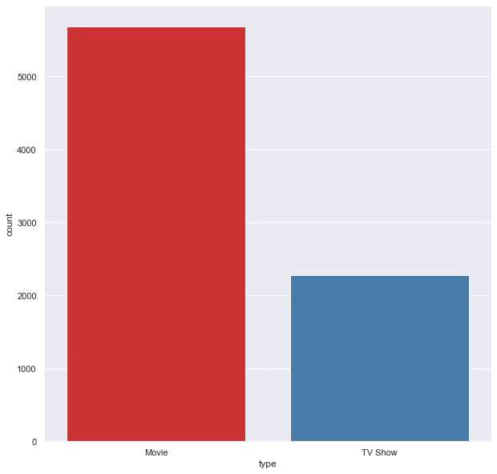

```python
plt.figure(figsize=(10,10))
sns.set(style="darkgrid")
graph = sns.countplot(x="type", data = netflix, palette= "Set1")
```

### 4.2 Amount of content by country

Under the country column, there are some rows where there are multiple countries name, so to resolve that we will take the first country in that row.

```python
#lambda function to split the countries by " " and taking the first country
netflix["firstCountry"] = netflix["country"].apply(lambda x: x.split(",")[0])

netflix['counter'] = 1
data = netflix.groupby('firstCountry')['counter'].sum().sort_values(ascending=False)[:8]
```

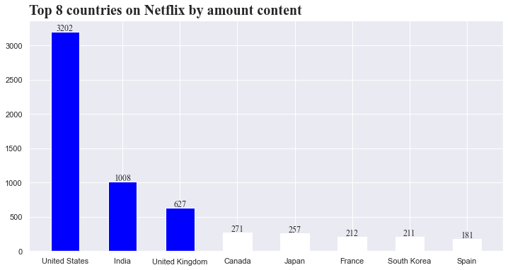

```python
#Draw figure/ setting colour
color = ['#FFFFFF' for i in range(10)]
color[0] = color[1]= color[2] = '#0000FF'
figure,axis = plt.subplots(1,1,figsize=(12,6))

#Annotate figure
axis.bar(data.index,data,width=0.5,color=color)
for i in data.index:
    axis.annotate(f"{data[i]}",xy=(i,data[i]+50),va='center',ha='center',fontweight='light',fontfamily='Times New Roman')

#Add text
figure.text(0.125,0.9,'Top 8 countries on Netflix by amount content',fontsize=20,fontweight='bold',fontfamily='Times New Roman')
```

Most of the content are made in the US, this could be due to the fact that Netflix is from the Us.

### 4.3.1 Movie ratings analysis

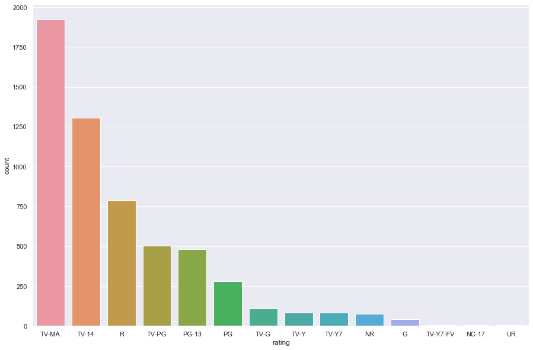

```python
plt.figure(figsize=(15,10))
graph = sns.countplot(x="rating", data=netflixMovies, order=netflixMovies['rating'].value_counts().index)
```

### 4.3.2 TV show ratings analysis

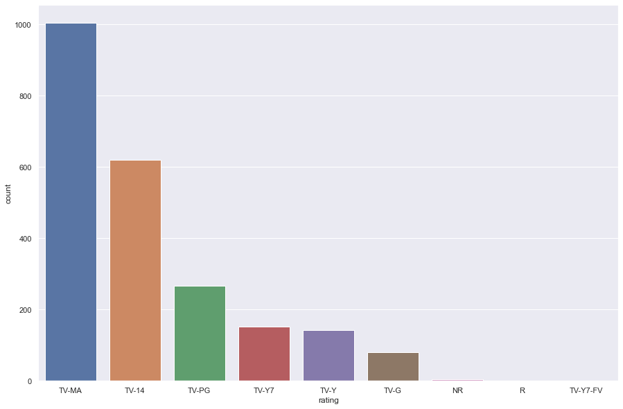

```python
plt.figure(figsize=(15,10))
graph = sns.countplot(x="rating", data=netflixShows, order=netflixShows['rating'].value_counts().index)
```

Both movies and TV shows have the most mature audience ratings. This tells me that netflix content is more driven towards 17 and above

### 4.4.1 No. of Movie released

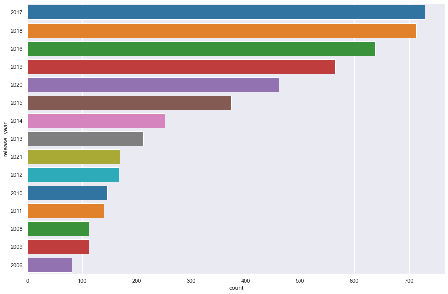

```python
plt.figure(figsize=(15,10))
graph = sns.countplot(y="release_year", data=netflixMovies, palette="tab10", order=netflixMovies['release_year'].value_counts().index[0:15])
```

### 4.4.2 No. of TV shows released

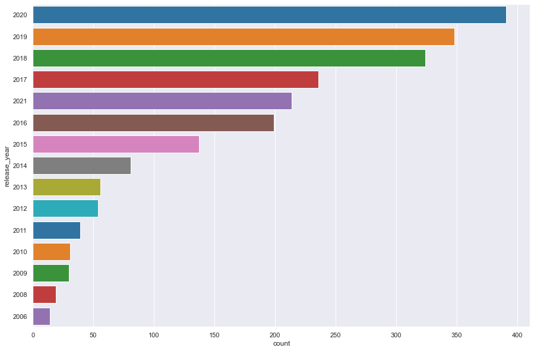

```python
plt.figure(figsize=(15,10))
graph = sns.countplot(y="release_year", data=netflixShows, palette="tab10", order=netflixShows['release_year'].value_counts().index[0:15])
```

2017 was the year with most movies released and 2020 with the most TV shows. I can also assume those are the years Netflix produced the most amount of movies and TV shows respectively.

### 4.5 TV shows with longest season

```python
#replace min in "duration" with " "
netflixMovies['duration']=netflixMovies['duration'].str.replace(' min','')

#convert string to integer
netflixMovies['duration']=netflixMovies['duration'].astype(str).astype(int)
```

```python
showLength = netflixShows[['title','duration']]
#replace Season and s in with " "
showLength['noOfSeasons'] = showLength['duration'].str.replace('Season','')
showLength['noOfSeasons'] = showLength['noOfSeasons'].str.replace('s','')

#convert string to integer
showLength['noOfSeasons'] = showLength['noOfSeasons'].astype(str).astype(int)
```

```python
topShows = showLength[['title','noOfSeasons']]
topShows = topShows.sort_values(by='noOfSeasons', ascending=False)
```

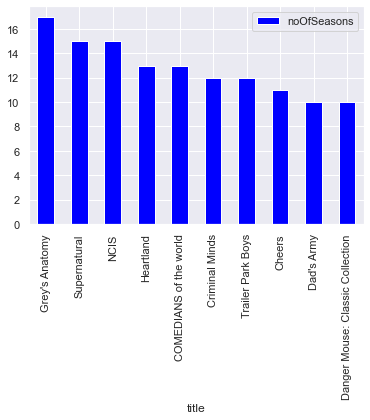

```python
first10 = topShows[0:10]
plt.figure(figsize = (15,10))
first10.plot(kind ='bar',x ='title',y = 'noOfSeasons', color='blue')
```

The bar graph shows the top 10 TV shows with the longest season with each show having at least 10 seasons.

### 4.6.1 Average movie duration

```
[Text(0.5, 0, 'Duration(mins)'), Text(0, 0.5, 'Density')]
```

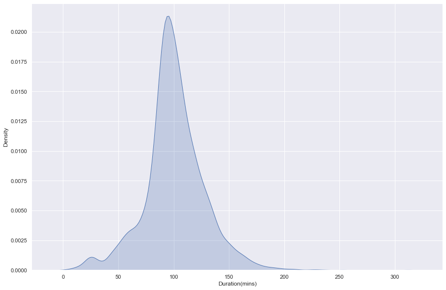

```python
plt.figure(figsize = (15,10))
graph = sns.kdeplot(data=netflixMovies['duration'], fill=True)
graph.set(xlabel ="Duration(mins)", ylabel = "Density")
```

### 4.6.2 Average TV shows duration

```
[Text(0.5, 0, 'Seasons'), Text(0, 0.5, 'Density')]
```

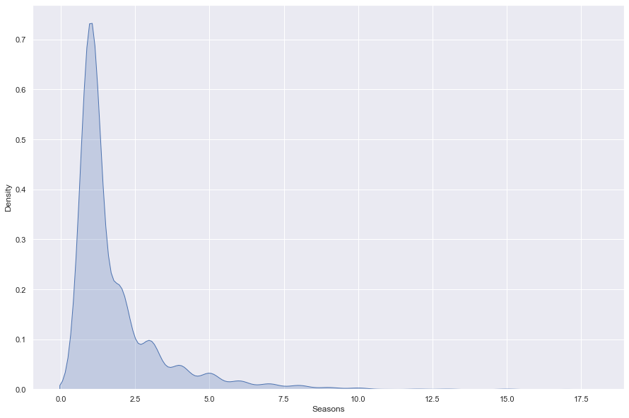

```python
plt.figure(figsize = (15,10))
graph = sns.kdeplot(data = showLength['noOfSeasons'], fill=True)
graph.set(xlabel ="Seasons", ylabel = "Density")
```

Based on the kernel density estimate plot, an average movie length lasts around 90-100 mins and an average TV Show last 1 season. I can infer that only Tv shows with high ratings will have more than 1 season which is rare.

## 5. Conclusion

Based on our data analysis, I was able to infer the relationships and trends based on the data. If I were given more data such as content ratings, such as 1 -5 stars I would be able to delve in deeper and get a clearer analysis.

## 6. References

seaborn

- https://seaborn.pydata.org/api.html
- NeuralNine (17 Apr 2022) Seaborn Is The Easier Matplotlib [online] Avialable: https://www.youtube.com/watch?v=ooqXQ37XHMM
- Kimberly Fessel (30 Jun 2020) What is kernel density estimation? And how to build a KDE plot in Python? | Seaborn KDEplot [online] Avialable: https://www.youtube.com/watch?v=DCgPRaIDYXA&t=384s

Matplotlib

- https://matplotlib.org/stable/api/index

plotly

- https://plotly.com/python-api-reference/generated/plotly.graph_objects.Figure.html

netflix data set

- SHIVAM BANSAL (Oct 2021) Netflix Movies and TV Shows [online] Avialable: https://www.kaggle.com/datasets/shivamb/netflix-shows